# DATA 607 Project 1: Chess Tournament Results

Fan Xu, Sin Ying Wong

9/21/2019

# 1. Project Description

In this project, you’re given a text file with chess tournament results where the information has some structure. Your job is to create an R Markdown file that generates a .CSV file (that could for example be imported into a SQL database) with the following information for all of the players:

Player’s Name, Player’s State, Total Number of Points, Player’s Pre-Rating, and Average Pre Chess Rating of Opponents For the first player, the information would be:

Gary Hua, ON, 6.0, 1794, 1605

1605 was calculated by using the pre-tournament opponents’ ratings of 1436, 1563, 1600, 1610, 1649, 1663, 1716, and dividing by the total number of games played.

If you have questions about the meaning of the data or the results, please post them on the discussion forum. Data science, like chess, is a game of back and forth…

The chess rating system (invented by a Minnesota statistician named Arpad Elo) has been used in many other contexts, including assessing relative strength of employment candidates by human resource departments.

You may substitute another text file (or set of text files, or data scraped from web pages) of similar or greater complexity, and create your own assignment and solution. You may work in a small team. All of your code should be in an R markdown file (and published to rpubs.com); with your data accessible for the person running the script.

# 2. Project Raw Data

The raw data is a text file with unstructured data strings.

```r
raw_data <- readLines('https://raw.githubusercontent.com/oggyluky11/DATA607-Project-1/master/tournamentinfo.txt')
head(raw_data)
```

```
## [1] "-----------------------------------------------------------------------------------------"
## [2] " Pair | Player Name                     |Total|Round|Round|Round|Round|Round|Round|Round| "
## [3] " Num  | USCF ID / Rtg (Pre->Post)       | Pts |  1  |  2  |  3  |  4  |  5  |  6  |  7  | "
## [4] "-----------------------------------------------------------------------------------------"
## [5] "    1 | GARY HUA                        |6.0  |W  39|W  21|W  18|W  14|W   7|D  12|D   4|"
## [6] "   ON | 15445895 / R: 1794   ->1817     |N:2  |W    |B    |W    |B    |W    |B    |W    |"
```

# 3. Raw Data Manipulation

## a. Restructure raw data into dataframe

In raw data, double lines of strings are used to store one ‘row’ of data. Data columns are seperated by “|”. Let’s see what this raw data should look like in a real data frame. This step is not requested in this project but it is good to represent the raw data into the way it should look like as data preparation.

```r
library(dplyr)
library(tidyr)
library(stringr)
#remove the last character "|"
raw_data <- str_trim(raw_data[str_detect(raw_data,'------')==FALSE],'right')
raw_data <- substr(raw_data, 1 ,nchar(raw_data)-1)

#Combine two lines of data into one row
raw_data2 <- character()
for (i in (1:length(raw_data))) {
  if(i%%2==0) {
    line_odd <- str_trim(unlist(str_split(raw_data[i-1], '\\|')))
    line_even <- str_trim(unlist(str_split(raw_data[i], '\\|')))
    line_cat <- str_c(line_odd,line_even,sep = ' ', collapse = ',')
    raw_data2 <- append(raw_data2,line_cat)
  }
}
raw_data2 <-data.frame(raw_data2)
raw_data_frame <- raw_data2 %>% separate(raw_data2, as.character(c(1:10)), sep = ',', extra = 'drop')

#Set first row as header and rename columns
names(raw_data_frame)<- unlist(raw_data_frame[1,])
raw_data_frame <- raw_data_frame[-1,]
raw_data_frame
```

|  | Pair Num | Player Name USCF ID / Rtg (Pre->Post) | Total Pts | Round 1 | Round 2 | Round 3 | Round 4 | Round 5 | Round 6 | Round 7 |
| --- | --- | --- | --- | --- | --- | --- | --- | --- | --- | --- |
| 2 | 1 ON | GARY HUA 15445895 / R: 1794 ->1817 | 6.0 N:2 | W 39 W | W 21 B | W 18 W | W 14 B | W 7 W | D 12 B | D 4 W |
| 3 | 2 MI | DAKSHESH DARURI 14598900 / R: 1553 ->1663 | 6.0 N:2 | W 63 B | W 58 W | L 4 B | W 17 W | W 16 B | W 20 W | W 7 B |
| 4 | 3 MI | ADITYA BAJAJ 14959604 / R: 1384 ->1640 | 6.0 N:2 | L 8 W | W 61 B | W 25 W | W 21 B | W 11 W | W 13 B | W 12 W |
| 5 | 4 MI | PATRICK H SCHILLING 12616049 / R: 1716 ->1744 | 5.5 N:2 | W 23 W | D 28 B | W 2 W | W 26 B | D 5 W | W 19 B | D 1 B |
| 6 | 5 MI | HANSHI ZUO 14601533 / R: 1655 ->1690 | 5.5 N:2 | W 45 B | W 37 W | D 12 B | D 13 W | D 4 B | W 14 W | W 17 B |
| 7 | 6 OH | HANSEN SONG 15055204 / R: 1686 ->1687 | 5.0 N:3 | W 34 W | D 29 B | L 11 W | W 35 B | D 10 B | W 27 W | W 21 B |
| 8 | 7 MI | GARY DEE SWATHELL 11146376 / R: 1649 ->1673 | 5.0 N:3 | W 57 W | W 46 B | W 13 W | W 11 B | L 1 B | W 9 W | L 2 W |
| 9 | 8 MI | EZEKIEL HOUGHTON 15142253 / R: 1641P17->1657P24 | 5.0 N:3 | W 3 B | W 32 W | L 14 B | L 9 W | W 47 B | W 28 W | W 19 W |
| 10 | 9 ON | STEFANO LEE 14954524 / R: 1411 ->1564 | 5.0 N:2 | W 25 W | L 18 B | W 59 W | W 8 B | W 26 W | L 7 B | W 20 B |
| 11 | 10 MI | ANVIT RAO 14150362 / R: 1365 ->1544 | 5.0 N:3 | D 16 W | L 19 W | W 55 B | W 31 B | D 6 W | W 25 B | W 18 W |

[output cut: 54 more lines]

## b. Get data elements

```r
data_elements <-data.frame(str_extract(raw_data_frame$`Pair Num`,'\\d+'), #Player's ID
  str_trim(str_extract(raw_data_frame$`Player Name USCF ID / Rtg (Pre->Post)`,'[A-Z ]+\\b')), #Player's Name
  str_extract(raw_data_frame$`Pair Num`,'[A-Z]+'), #Player's State
  str_extract(raw_data_frame$`Total Pts`,'[0-9.]+'), #Player's Total Points
  str_replace(raw_data_frame$`Player Name USCF ID / Rtg (Pre->Post)`, '[A-z0-9 [:PUNCT:]]+\\/ R\\: *([0-9]+)([A-Z0-9]+)? *.+', '\\1'), #player's Rating
  lapply(raw_data_frame[,4:10], function(x) str_extract(x, '\\d+'))) #IDs of components

#Rename columns
names(data_elements) <- c('ID','Player’s Name','Player’s State','Total Number of Points','Player’s Pre-Rating','Round 1','Round 2','Round 3','Round 4','Round 5','Round 6','Round 7')

#change data type of 'Player’s Pre-Rating' to be numberic
data_elements$'Player’s Pre-Rating' <- as.numeric(as.character(data_elements$'Player’s Pre-Rating'))

#get ratings of all components for each player
data_elements[,6:12] <- data_elements$'Player’s Pre-Rating'[match(unlist(data_elements[,6:12]),data_elements$ID)]

#compute average ratings of components for each player
data_elements$'Average Pre Chess Rating of Opponents' <- round(rowMeans(data_elements[,6:12],na.rm = TRUE),0)
data_elements
```

| ID | Player’s Name | Player’s State | Total Number of Points | Player’s Pre-Rating | Round 1 | Round 2 | Round 3 | Round 4 | Round 5 | Round 6 | Round 7 | Average Pre Chess Rating of Opponents |
| --- | --- | --- | --- | --- | --- | --- | --- | --- | --- | --- | --- | --- |
| 1 | GARY HUA | ON | 6.0 | 1794 | 1436 | 1563 | 1600 | 1610 | 1649 | 1663 | 1716 | 1605 |
| 2 | DAKSHESH DARURI | MI | 6.0 | 1553 | 1175 | 917 | 1716 | 1629 | 1604 | 1595 | 1649 | 1469 |
| 3 | ADITYA BAJAJ | MI | 6.0 | 1384 | 1641 | 955 | 1745 | 1563 | 1712 | 1666 | 1663 | 1564 |
| 4 | PATRICK H SCHILLING | MI | 5.5 | 1716 | 1363 | 1507 | 1553 | 1579 | 1655 | 1564 | 1794 | 1574 |
| 5 | HANSHI ZUO | MI | 5.5 | 1655 | 1242 | 980 | 1663 | 1666 | 1716 | 1610 | 1629 | 1501 |
| 6 | HANSEN SONG | OH | 5.0 | 1686 | 1399 | 1602 | 1712 | 1438 | 1365 | 1552 | 1563 | 1519 |
| 7 | GARY DEE SWATHELL | MI | 5.0 | 1649 | 1092 | 377 | 1666 | 1712 | 1794 | 1411 | 1553 | 1372 |
| 8 | EZEKIEL HOUGHTON | MI | 5.0 | 1641 | 1384 | 1441 | 1610 | 1411 | 1362 | 1507 | 1564 | 1468 |
| 9 | STEFANO LEE | ON | 5.0 | 1411 | 1745 | 1600 | 853 | 1641 | 1579 | 1649 | 1595 | 1523 |
| 10 | ANVIT RAO | MI | 5.0 | 1365 | 1604 | 1564 | 1186 | 1494 | 1686 | 1745 | 1600 | 1554 |

[output cut: 54 more lines]

# 3. Present final data

```r
final_data <- subset(data_elements[,c(2:5,13)])
final_data
```

|  | Player’s Name | Player’s State | Total Number of Points | Player’s Pre-Rating | Average Pre Chess Rating of Opponents |
| --- | --- | --- | --- | --- | --- |
| 1 | GARY HUA | ON | 6.0 | 1794 | 1605 |
| 2 | DAKSHESH DARURI | MI | 6.0 | 1553 | 1469 |
| 3 | ADITYA BAJAJ | MI | 6.0 | 1384 | 1564 |
| 4 | PATRICK H SCHILLING | MI | 5.5 | 1716 | 1574 |
| 5 | HANSHI ZUO | MI | 5.5 | 1655 | 1501 |
| 6 | HANSEN SONG | OH | 5.0 | 1686 | 1519 |
| 7 | GARY DEE SWATHELL | MI | 5.0 | 1649 | 1372 |
| 8 | EZEKIEL HOUGHTON | MI | 5.0 | 1641 | 1468 |
| 9 | STEFANO LEE | ON | 5.0 | 1411 | 1523 |
| 10 | ANVIT RAO | MI | 5.0 | 1365 | 1554 |

[output cut: 54 more lines]

# 4. Save Final Data as CSV

```r
write.csv(final_data, 'Final_data.csv', row.names = FALSE)

# Let's check the csv output, looks good:)
read.csv('Final_data.csv')
```

| Player.s.Name | Player.s.State | Total.Number.of.Points | Player.s.Pre.Rating | Average.Pre.Chess.Rating.of.Opponents |
| --- | --- | --- | --- | --- |
| GARY HUA | ON | 6.0 | 1794 | 1605 |
| DAKSHESH DARURI | MI | 6.0 | 1553 | 1469 |
| ADITYA BAJAJ | MI | 6.0 | 1384 | 1564 |
| PATRICK H SCHILLING | MI | 5.5 | 1716 | 1574 |
| HANSHI ZUO | MI | 5.5 | 1655 | 1501 |
| HANSEN SONG | OH | 5.0 | 1686 | 1519 |
| GARY DEE SWATHELL | MI | 5.0 | 1649 | 1372 |
| EZEKIEL HOUGHTON | MI | 5.0 | 1641 | 1468 |
| STEFANO LEE | ON | 5.0 | 1411 | 1523 |
| ANVIT RAO | MI | 5.0 | 1365 | 1554 |

[output cut: 54 more lines]

# 5. Extra Data Analysis

It is fun and challenge in a chess tournament where players are paried according to a certain rating algorithm which matches players with compatible components, which means if a player has high winning rate, he/she will be more likely to paired with a strong component in the next run. Let’s see if this is the case in this data set.

```r
library(reshape2)
# extract a new subset of data which records results of each round, then compute the wining-rate of each player.
data <- data.frame(lapply(raw_data_frame[,c(2,4:10)], function(x) str_trim(str_extract(str_trim(x),'^[A-z ]{2,}'))),stringsAsFactors = FALSE)

# For a more accurate winning-rate, in this data set only players who completed all 7 rounds of game are selected.
data <-na.omit(data)
names(data)<-c('Name', str_c('Round_', c(1:7)))
data
```

|  | Name | Round_1 | Round_2 | Round_3 | Round_4 | Round_5 | Round_6 | Round_7 |
| --- | --- | --- | --- | --- | --- | --- | --- | --- |
| 1 | GARY HUA | W | W | W | W | W | D | D |
| 2 | DAKSHESH DARURI | W | W | L | W | W | W | W |
| 3 | ADITYA BAJAJ | L | W | W | W | W | W | W |
| 4 | PATRICK H SCHILLING | W | D | W | W | D | W | D |
| 5 | HANSHI ZUO | W | W | D | D | D | W | W |
| 6 | HANSEN SONG | W | D | L | W | D | W | W |
| 7 | GARY DEE SWATHELL | W | W | W | W | L | W | L |
| 8 | EZEKIEL HOUGHTON | W | W | L | L | W | W | W |
| 9 | STEFANO LEE | W | L | W | W | W | L | W |
| 10 | ANVIT RAO | D | L | W | W | D | W | W |

[output cut: 31 more lines]

```r
# Reshape the data and compute winning-rate
data_melt <- melt(data, variable.name = 'Round', value.name = 'Result', id.vars = c('Name'))
data_cast <- dcast(data_melt, Name~Result, fun.aggregate = length)
data_cast$Win_Rtg <-data_cast$W/7

# Join the final_data set in previous section
data_join <-merge(data_cast,final_data,by.x=c('Name'),by.y=c('Player’s Name'))
data_join$Rtg_Diff <- data_join[,9]-data_join[,8]
data_join$Win_Seg <-ifelse(data_join$Win_Rtg>=0.5, 'Winning_Rate >= 50%', 'Winning_Rate < 50%')
data_join
```

| Name | D | L | W | Win_Rtg | Player’s State | Total Number of Points | Player’s Pre-Rating | Average Pre Chess Rating of Opponents | Rtg_Diff | Win_Seg |
| --- | --- | --- | --- | --- | --- | --- | --- | --- | --- | --- |
| ADITYA BAJAJ | 0 | 1 | 6 | 0.8571429 | MI | 6.0 | 1384 | 1564 | 180 | Winning_Rate >= 50% |
| ALAN BUI | 0 | 3 | 4 | 0.5714286 | ON | 4.0 | 1363 | 1214 | -149 | Winning_Rate >= 50% |
| ANVIT RAO | 2 | 1 | 4 | 0.5714286 | MI | 5.0 | 1365 | 1554 | 189 | Winning_Rate >= 50% |
| BEN LI | 2 | 5 | 0 | 0.0000000 | MI | 1.0 | 1163 | 1263 | 100 | Winning_Rate < 50% |
| BRADLEY SHAW | 1 | 2 | 4 | 0.5714286 | MI | 4.5 | 1610 | 1515 | -95 | Winning_Rate >= 50% |
| CAMERON WILLIAM MC LEMAN | 1 | 2 | 4 | 0.5714286 | MI | 4.5 | 1712 | 1468 | -244 | Winning_Rate >= 50% |
| DAKSHESH DARURI | 0 | 1 | 6 | 0.8571429 | MI | 6.0 | 1553 | 1469 | -84 | Winning_Rate >= 50% |
| DAVID SUNDEEN | 0 | 3 | 4 | 0.5714286 | MI | 4.0 | 1600 | 1480 | -120 | Winning_Rate >= 50% |
| DEREK YAN | 2 | 3 | 2 | 0.2857143 | MI | 3.0 | 1242 | 1152 | -90 | Winning_Rate < 50% |
| DINH DANG BUI | 0 | 3 | 4 | 0.5714286 | ON | 4.0 | 1563 | 1470 | -93 | Winning_Rate >= 50% |

[output cut: 31 more lines]

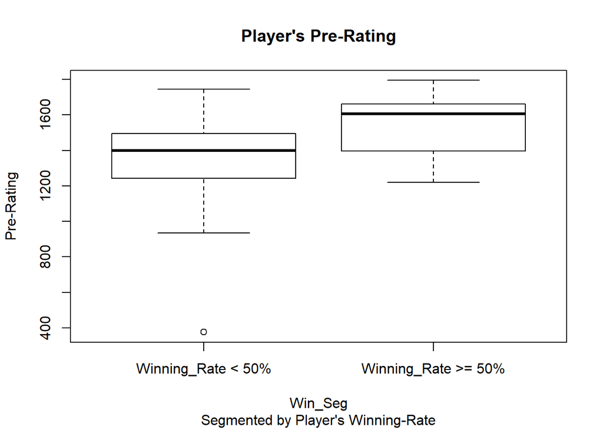

```r
boxplot(data_join$"Player’s Pre-Rating"~Win_Seg, data=data_join, main="Player's Pre-Rating",
        sub="Segmented by Player's Winning-Rate", ylab = 'Pre-Rating')
```

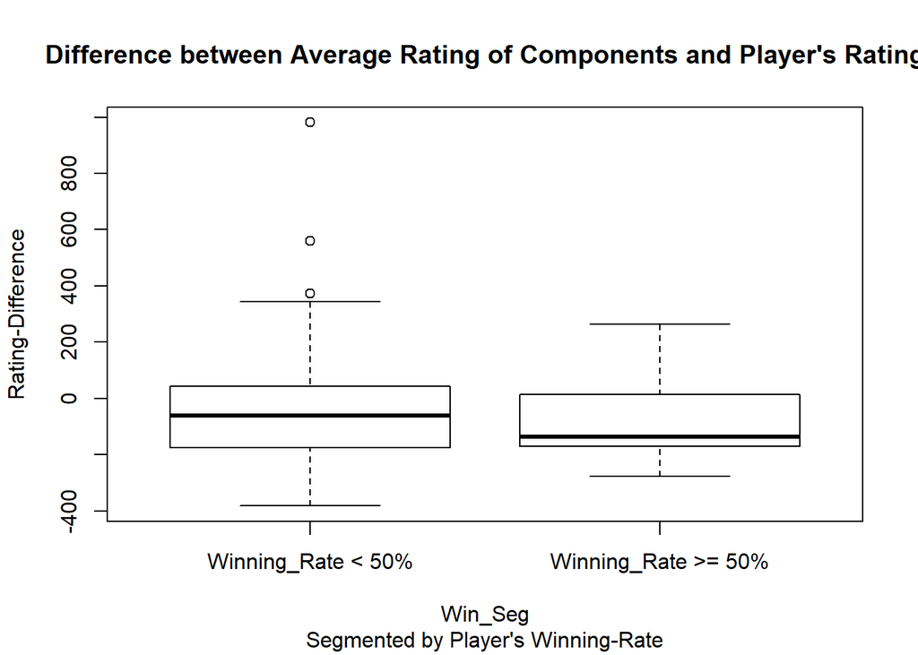

```r
boxplot(Rtg_Diff~Win_Seg, data=data_join,
        main="Difference between Average Rating of Components and Player's Rating",
        sub="Segmented by Player's Winning-Rate", ylab = 'Rating-Difference')
```